# HW8_20203374_이호용

## 1 - (1)

### 1. Load data and fit the model

```r
rm(list=ls())
load('C:/Users/Hoyong/Downloads/RABE5.RData')
df <- P248
head(df)
```

```
##         St      At  Pt   Et    At.1 Pt.1
## 1 20.11371 1.98786 1.0 0.30 2.01722  0.0
## 2 15.10439 1.94418 0.0 0.30 1.98786  1.0
## 3 18.68375 2.19954 0.8 0.35 1.94418  0.0
## 4 16.05173 2.00107 0.0 0.35 2.19954  0.8
## 5 21.30101 1.69292 1.3 0.30 2.00107  0.0
## 6 17.85004 1.74334 0.3 0.32 1.69292  1.3
```

```r
lm <- lm(St ~ ., data = df)
summary(lm)
```

```
##
## Call:
## lm(formula = St ~ ., data = df)
##
## Residuals:
##     Min      1Q  Median      3Q     Max
## -1.8601 -0.9848  0.1323  0.7017  2.2046
##
## Coefficients:
##             Estimate Std. Error t value Pr(>|t|)
## (Intercept)  -14.194     18.715  -0.758   0.4592
## At             5.361      4.028   1.331   0.2019
## Pt             8.372      3.586   2.334   0.0329 *
## Et            22.521      2.142  10.512 1.36e-08 ***
## At.1           3.855      3.578   1.077   0.2973
## Pt.1           4.125      3.895   1.059   0.3053
## ---
## Signif. codes:  0 '***' 0.001 '**' 0.01 '*' 0.05 '.' 0.1 ' ' 1
##
## Residual standard error: 1.32 on 16 degrees of freedom
## Multiple R-squared:  0.9169, Adjusted R-squared:  0.8909
## F-statistic:  35.3 on 5 and 16 DF,  p-value: 4.289e-08
```

$R^2$ = 0.9169, $R_{a}^2$ = 0.8909, $\hat{\sigma}$=1.32. The results above show that the model is significant. However, some of the explanatory variables(which seems important, [At, At.1, Pt.1]) *aren’t significant*.  
So, as they are not significant, *multicollinearity is suspicious*.

```r
library(leaps)
lm_test <- regsubsets(St ~ . , data = df)
summary(lm_test)
```

```
## Subset selection object
## Call: regsubsets.formula(St ~ ., data = df)
## 5 Variables  (and intercept)
##      Forced in Forced out
## At       FALSE      FALSE
## Pt       FALSE      FALSE
## Et       FALSE      FALSE
## At.1     FALSE      FALSE
## Pt.1     FALSE      FALSE
## 1 subsets of each size up to 5
## Selection Algorithm: exhaustive
##          At  Pt  Et  At.1 Pt.1
## 1  ( 1 ) " " " " "*" " "  " "
## 2  ( 1 ) " " "*" "*" " "  " "
## 3  ( 1 ) "*" "*" "*" " "  " "
## 4  ( 1 ) "*" "*" "*" "*"  " "
## 5  ( 1 ) "*" "*" "*" "*"  "*"
```

```r
coef(lm_test, 1:5)
```

```
## [[1]]
## (Intercept)          Et
##    11.01564    23.23717
##
## [[2]]
## (Intercept)          Pt          Et
##    8.261503    4.226087   22.355881
##
## [[3]]
## (Intercept)          At          Pt          Et
##    5.830018    1.123583    4.594245   22.729170
##
## [[4]]
## (Intercept)          At          Pt          Et        At.1
##   5.3768971   1.1702953   4.6526433  22.8134739   0.1590089
##
## [[5]]
## (Intercept)          At          Pt          Et        At.1        Pt.1
##  -14.193665    5.360750    8.372320   22.521032    3.854568    4.124794
```

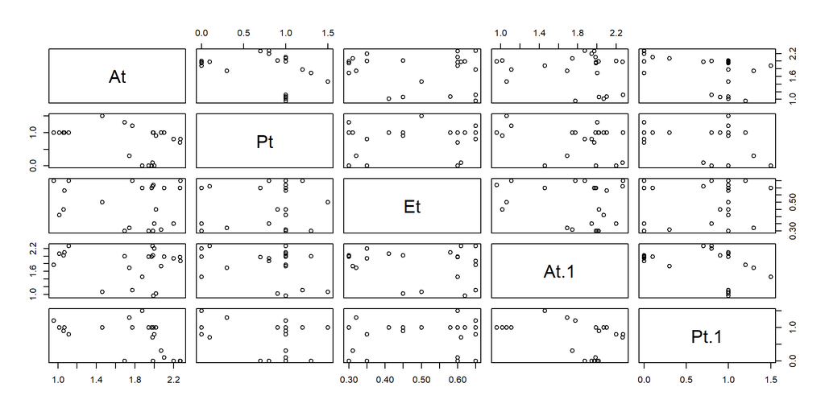

```r
plot(df[,-1])
```

It doesn’t seems like highly correlated. But that doesn’t mean low correlation.

### 2. Regression Diagnostics

Checking Leverage

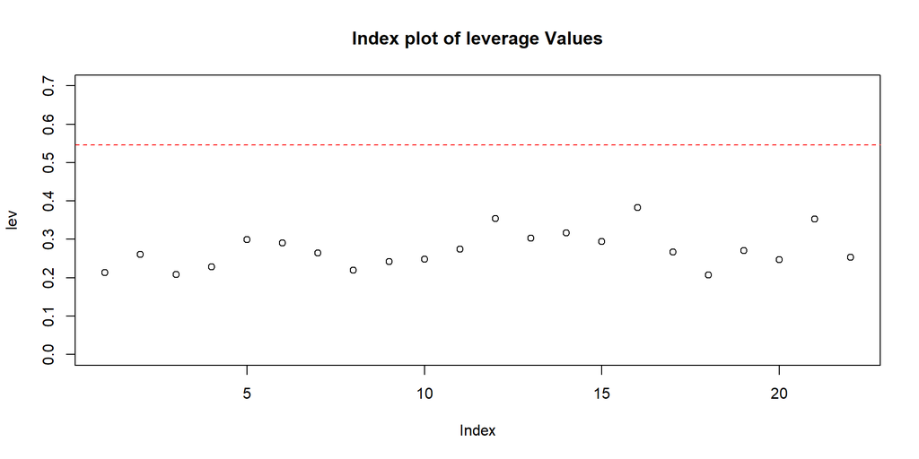

```r
p <- length(lm$coefficients)-1 ; n <- dim(df)[1]
lev <- influence(lm)$hat
reference_value <- 2*(p+1)/n
plot(lev, main='Index plot of leverage Values', ylim= c(0, 0.7)) # Calculate high leverage and plot lines.
abline(h = reference_value, lty=2, col = 'red') # identify(lev) no high leverage so I hide the code
```

Checking Influential

```r
dffits <- dffits(lm) # Using DFFITS to find influential points.
ref <- 2*sqrt((p+1)/(n-p-1))
```

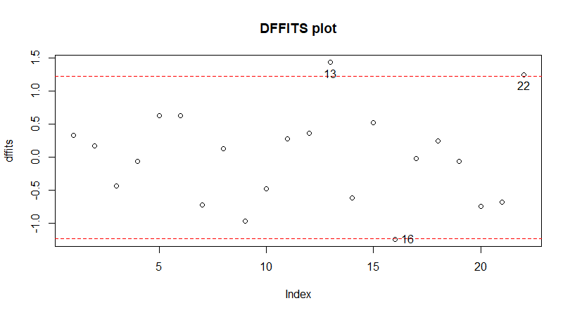

```r
plot(dffits, main='DFFITS plot')
abline(h= c(-ref,ref), col='red', lty=2)
identify(dffits)
```

```r
dffits[16] < -ref
```

```
##   16
## TRUE
```

*Influential = (13, 16, 22)th point.*

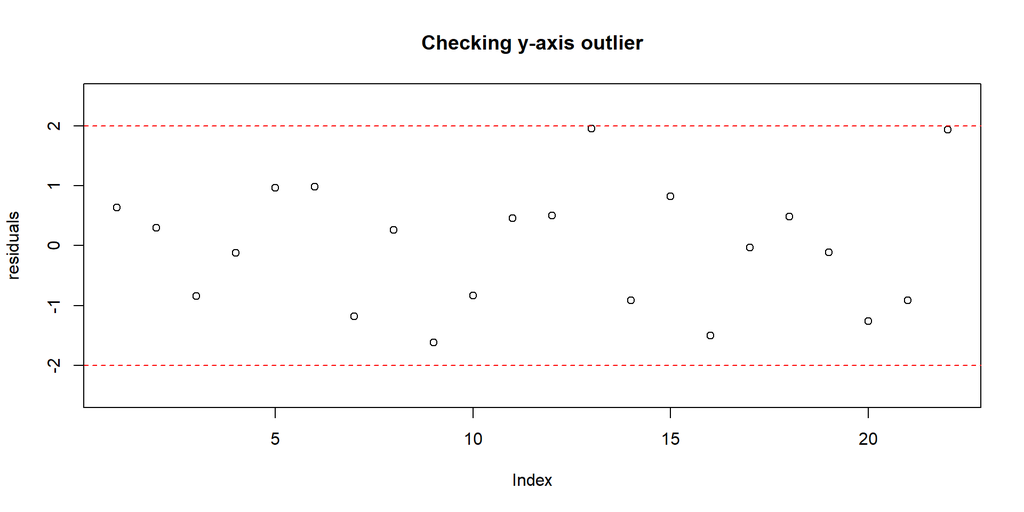

```r
residuals <- rstandard(lm) # Checking y-axis outliers w/ residual plot
plot(residuals, main='Checking y-axis outlier', ylim=c(-2.5, 2.5))
abline(h=c(-2,2), col='red', lty=2) # identify(residuals)
```

Influential points were (13, 16, 22). After removing those points check if there’s any difference.

```r
lm_rmvd <- lm(lm, subset=-c(13, 16, 22))
summary(lm_rmvd)
```

```
##
## Call:
## lm(formula = lm, subset = -c(13, 16, 22))
##
## Residuals:
##     Min      1Q  Median      3Q     Max
## -2.0173 -0.6349  0.1384  0.5963  1.2210
##
## Coefficients:
##             Estimate Std. Error t value Pr(>|t|)
## (Intercept)   -2.709     17.018  -0.159   0.8760
## At             2.949      3.701   0.797   0.4398
## Pt             6.334      3.261   1.942   0.0741 .
## Et            21.323      1.898  11.236 4.58e-08 ***
## At.1           1.631      3.261   0.500   0.6252
## Pt.1           2.301      3.579   0.643   0.5315
## ---
## Signif. codes:  0 '***' 0.001 '**' 0.01 '*' 0.05 '.' 0.1 ' ' 1
##
## Residual standard error: 1.027 on 13 degrees of freedom
## Multiple R-squared:  0.9475, Adjusted R-squared:  0.9273
## F-statistic: 46.91 on 5 and 13 DF,  p-value: 7.265e-08
```

Still At, At.1, Pt.1 are not significant. *Multicollinearity is suspicious.*  
We have to check multicollinearity with numerical methods.

### 3. Checking multicollinearity

```r
library(car)
vif(lm); mean(vif(lm))
```

```
##        At        Pt        Et      At.1      Pt.1
## 36.941513 33.473514  1.075962 25.915651 43.520965
```

```
## [1] 28.18552
```

VIF of (At, Pt, At.1, Pt.1) > 10. *It seems to have multicollinearity.*

```r
library(perturb)
colldiag(lm, center = TRUE, scale = TRUE)
```

```
## Condition
## Index    Variance Decomposition Proportions
##           At    Pt    Et    At.1  Pt.1
## 1   1.000 0.005 0.001 0.083 0.004 0.005
## 2   1.149 0.000 0.016 0.000 0.002 0.004
## 3   1.219 0.011 0.001 0.038 0.016 0.000
## 4   1.407 0.000 0.000 0.867 0.005 0.002
## 5  15.295 0.985 0.983 0.012 0.973 0.989
```

Condition Index = 15.295 > 15. *It seems to have multicollinearity.*

## 1 - (2)

### 1. Fit the model and search the reasons of multicollinearity

```r
lm_2 <- lm(At ~ Pt + At.1 + Pt.1, data=df)
summary(lm_2)
```

```
##
## Call:
## lm(formula = At ~ Pt + At.1 + Pt.1, data = df)
##
## Residuals:
##       Min        1Q    Median        3Q       Max
## -0.134930 -0.052396 -0.004111  0.063809  0.146043
##
## Coefficients:
##             Estimate Std. Error t value Pr(>|t|)
## (Intercept)  4.63124    0.12937   35.80  < 2e-16 ***
## Pt          -0.86953    0.04333  -20.07 9.08e-14 ***
## At.1        -0.86340    0.05024  -17.18 1.30e-12 ***
## Pt.1        -0.94689    0.04192  -22.59 1.17e-14 ***
## ---
## Signif. codes:  0 '***' 0.001 '**' 0.01 '*' 0.05 '.' 0.1 ' ' 1
##
## Residual standard error: 0.0776 on 18 degrees of freedom
## Multiple R-squared:  0.9727, Adjusted R-squared:  0.9681
## F-statistic: 213.6 on 3 and 18 DF,  p-value: 2.951e-14
```

Above table shows that, $A_t$ = 4.6312397 -0.8695297Pt -0.8634026At.1 -0.9468857Pt.1.  
$A_t$ + $P_t$ + $A_{t-1}$ + $P_{t-1}$ $\approx$ 5.And $R^2$ $\approx1$ and $\hat{\sigma}$ = 0.0776.  
Those results show that *explanatory variables explain each other well.*  
It seems to be the reason of *multicollinearity.*

```r
lm_rmvd_at <- lm(St ~ Pt + Et + At.1 + Pt.1, data = df)
summary(lm_rmvd_at)$coefficient # Without At model
```

```
##               Estimate Std. Error    t value     Pr(>|t|)
## (Intercept) 10.5093791  2.4576053  4.2762682 5.104009e-04
## Pt           3.7017522  0.7571163  4.8892784 1.382332e-04
## Et          22.7941828  2.1803508 10.4543650 8.040870e-09
## At.1        -0.7691882  0.8745644 -0.8795101 3.913880e-01
## Pt.1        -0.9686601  0.7422533 -1.3050263 2.092730e-01
```

```r
summary(lm)$coefficient # Full model
```

```
##               Estimate Std. Error    t value     Pr(>|t|)
## (Intercept) -14.193665  18.715105 -0.7584069 4.592340e-01
## At            5.360750   4.027686  1.3309754 2.018535e-01
## Pt            8.372320   3.586411  2.3344563 3.293210e-02
## Et           22.521032   2.142351 10.5122957 1.364688e-08
## At.1          3.854568   3.577717  1.0773819 2.972862e-01
## Pt.1          4.124794   3.895108  1.0589678 3.053404e-01
```

Compare full model and without At model, coefficients changed a lots.  
It seems have a *multicollinearity.*

## 1 - (3)

### 1. Calculate correlation matrix

```r
M <- cor(df[-1])
M
```

```
##              At          Pt          Et       At.1       Pt.1
## At    1.0000000 -0.35695388 -0.12852101 -0.1397402 -0.4959912
## Pt   -0.3569539  1.00000000  0.06258872 -0.3164655 -0.2963645
## Et   -0.1285210  0.06258872  1.00000000 -0.1664279  0.2081124
## At.1 -0.1397402 -0.31646549 -0.16642794  1.0000000 -0.3577610
## Pt.1 -0.4959912 -0.29636446  0.20811237 -0.3577610  1.0000000
```

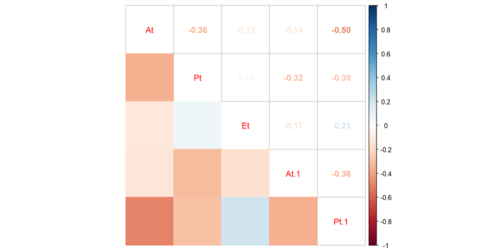

```r
library(corrplot)
corrplot.mixed(M, lower="color",upper="number")
```

### 2. Calculate eigen value, eigen vectors

```r
eigen(cor(df[-1]))
```

```
## eigen() decomposition
## $values
## [1] 1.700954740 1.288206906 1.144651635 0.858915342 0.007271377
##
## $vectors
##            [,1]        [,2]        [,3]        [,4]         [,5]
## [1,]  0.5324451  0.02378983  0.66774028 -0.07441699 -0.514316280
## [2,] -0.2324522 -0.82494494 -0.15779276  0.03710662 -0.489036183
## [3,] -0.3890860  0.02207954  0.21720985 -0.89490232  0.009709995
## [4,]  0.3952282  0.25963783 -0.69191108 -0.33801805 -0.428235605
## [5,] -0.5957138  0.50099959  0.05747436  0.27924692 -0.559323125
```

## 1 - (4)

### 1. Make Principal Component and calculate mean, std

```r
pca <- prcomp(df[-1], center = TRUE, scale = TRUE)
pca
```

```
## Standard deviations (1, .., p=5):
## [1] 1.30420656 1.13499203 1.06988394 0.92677686 0.08527237
##
## Rotation (n x k) = (5 x 5):
##             PC1         PC2         PC3         PC4          PC5
## At   -0.5324451  0.02378983 -0.66774028 -0.07441699  0.514316280
## Pt    0.2324522 -0.82494494  0.15779276  0.03710662  0.489036183
## Et    0.3890860  0.02207954 -0.21720985 -0.89490232 -0.009709995
## At.1 -0.3952282  0.25963783  0.69191108 -0.33801805  0.428235605
## Pt.1  0.5957138  0.50099959 -0.05747436  0.27924692  0.559323125
```

```r
pca$x # calculation of PC
```

```
##              PC1         PC2         PC3         PC4          PC5
##  [1,] -1.7829643 -1.04159040  0.48018770  0.63070741 -0.032217655
##  [2,] -0.9803141  1.73963422  0.04034456  1.15493518 -0.020503460
##  [3,] -1.9323812 -0.71330155 -0.11407544  0.31790618 -0.072031838
##  [4,] -1.3588448  1.67937036  0.25598832  0.53531692  0.035199617
##  [5,] -1.2560429 -1.60054799  1.00787320  0.71847616 -0.082345329
##  [6,]  0.1222935  1.32046686 -0.11365119  1.49989937  0.091975323
##  [7,] -1.2241214 -0.90097843 -0.15782938  0.95022578  0.120963504
##  [8,]  0.8840983 -0.01753016  1.76986030  0.62071217  0.012152787
##  [9,]  0.7327470 -0.44522991 -1.64147934  1.05210006 -0.009460577
## [10,]  0.8675428 -0.14314601  1.56686824  0.34047062 -0.105115255
## [11,]  1.8144751 -1.50501940 -0.58199707  0.83836323  0.003290830
## [12,]  1.0607816  1.96242304 -1.27080077 -0.03667233 -0.101403042
## [13,] -1.1164840 -0.70564562 -0.80781366 -1.56234475 -0.080425327
## [14,]  0.9984814 -0.05175803  1.61502028 -1.21657686  0.089413943
## [15,]  1.6494347 -0.89949500 -1.31467617 -0.24350931  0.101532318
## [16,]  2.1537515  0.03578593  0.96409079 -0.55151054 -0.152475070
## [17,]  1.3497159 -0.63441152 -1.92500244  0.02245596 -0.012191291
## [18,] -0.1777530  1.78951410 -0.46581898 -0.77582670 -0.008021589
## [19,] -1.3923707 -0.47549668 -0.59406529 -1.32780812 -0.087869362
## [20,] -0.7481278  1.48146593  0.03609396 -1.23405851  0.056324392
## [21,] -0.9293897 -0.90662257 -0.22890581 -1.22846628  0.159594824
## [22,]  1.2654721  0.03211282  1.47978820 -0.50479562  0.093612256
```

```r
names(pca)
```

```
## [1] "sdev"     "rotation" "center"   "scale"    "x"
```

```r
pca$sdev # standard deviation
```

```
## [1] 1.30420656 1.13499203 1.06988394 0.92677686 0.08527237
```

```r
apply(pca$x,2, mean) # mean
```

```
##           PC1           PC2           PC3           PC4           PC5
##  1.014715e-17 -1.154270e-16 -1.526557e-16 -3.532528e-17  5.582502e-17
```

## 1 - (5)

### 1. Principal Component Regression

```r
pca$x[,2:4] <- -pca$x[,2:4]
lm_pca_full <- lm(df$St ~ pca$x)
summary(lm_pca_full)
```

```
##
## Call:
## lm(formula = df$St ~ pca$x)
##
## Residuals:
##     Min      1Q  Median      3Q     Max
## -1.8601 -0.9848  0.1323  0.7017  2.2046
##
## Coefficients:
##             Estimate Std. Error t value Pr(>|t|)
## (Intercept)  22.4758     0.2814  79.864  < 2e-16 ***
## pca$xPC1      1.4601     0.2209   6.611 5.99e-06 ***
## pca$xPC2      1.6663     0.2538   6.566 6.50e-06 ***
## pca$xPC3      0.6469     0.2692   2.403   0.0288 *
## pca$xPC4      2.8120     0.3108   9.047 1.09e-07 ***
## pca$xPC5      4.8726     3.3780   1.442   0.1685
## ---
## Signif. codes:  0 '***' 0.001 '**' 0.01 '*' 0.05 '.' 0.1 ' ' 1
##
## Residual standard error: 1.32 on 16 degrees of freedom
## Multiple R-squared:  0.9169, Adjusted R-squared:  0.8909
## F-statistic:  35.3 on 5 and 16 DF,  p-value: 4.289e-08
```

Above table shows that *the model is significant.*  
All Coefficients except PC5 are significant. We have to check whether PC5 is necessary or not.

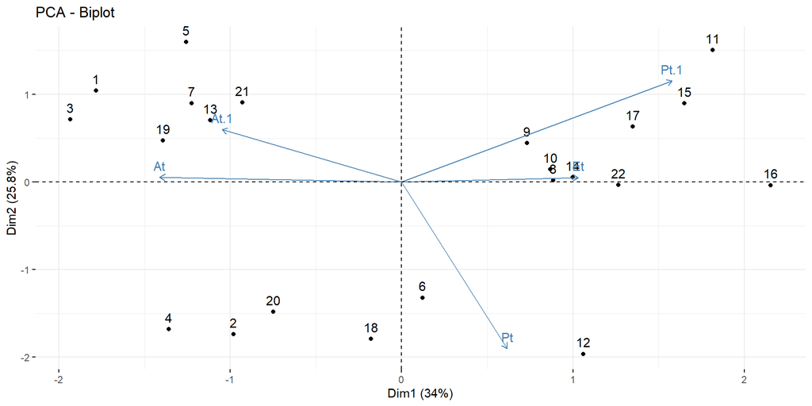

```r
library(factoextra)
fviz_pca_biplot(pca, repel = FALSE)
```

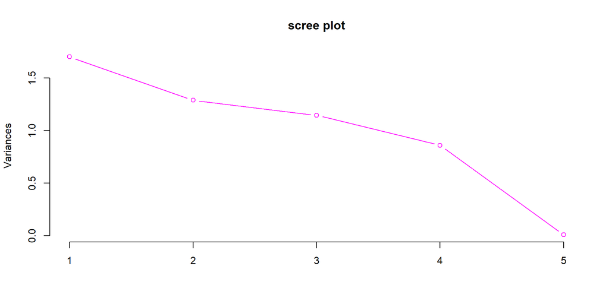

```r
screeplot(pca, col = 'magenta', type="lines", pch=1, main="scree plot")
```

Visually, we might notice PC5 is unnecessary.(point4 looks like elbow point).  
But PC4 is uncertain and let’s check with hypothesis tests.

```r
summary(pca)
```

```
## Importance of components:
##                           PC1    PC2    PC3    PC4     PC5
## Standard deviation     1.3042 1.1350 1.0699 0.9268 0.08527
## Proportion of Variance 0.3402 0.2576 0.2289 0.1718 0.00145
## Cumulative Proportion  0.3402 0.5978 0.8268 0.9986 1.00000
```

And this results show that Cumulative Proportion of PC3 = 0.82676 which is already high.  
Above results show that we need to operate joint hypothesis tests.

### 2. Simple hypothesis test

$H_0 : \alpha_5 = 0$  
$H_1 : \alpha_5\neq 0$, $\alpha=0.05$.

```r
lm_reduced <- lm(df$St ~ pca$x[,1] + pca$x[,2] + pca$x[,3] + pca$x[,4])
anova(lm_reduced, lm_pca_full)
```

```
## Analysis of Variance Table
##
## Model 1: df$St ~ pca$x[, 1] + pca$x[, 2] + pca$x[, 3] + pca$x[, 4]
## Model 2: df$St ~ pca$x
##   Res.Df    RSS Df Sum of Sq      F Pr(>F)
## 1     17 31.504
## 2     16 27.879  1    3.6255 2.0807 0.1685
```

p-value = 0.1684607 > 0.05($\alpha$). *Accept* $H_0$*. PC5 is not significant.*

```r
summary(lm_reduced)
```

```
##
## Call:
## lm(formula = df$St ~ pca$x[, 1] + pca$x[, 2] + pca$x[, 3] + pca$x[,
##     4])
##
## Residuals:
##      Min       1Q   Median       3Q      Max
## -2.29768 -0.69791  0.03269  0.57549  2.66077
##
## Coefficients:
##             Estimate Std. Error t value Pr(>|t|)
## (Intercept)  22.4758     0.2902  77.440  < 2e-16 ***
## pca$x[, 1]    1.4601     0.2278   6.410 6.46e-06 ***
## pca$x[, 2]    1.6663     0.2617   6.366 7.03e-06 ***
## pca$x[, 3]    0.6469     0.2777   2.330   0.0324 *
## pca$x[, 4]    2.8120     0.3205   8.773 1.02e-07 ***
## ---
## Signif. codes:  0 '***' 0.001 '**' 0.01 '*' 0.05 '.' 0.1 ' ' 1
##
## Residual standard error: 1.361 on 17 degrees of freedom
## Multiple R-squared:  0.9061, Adjusted R-squared:  0.884
## F-statistic:    41 on 4 and 17 DF,  p-value: 1.614e-08
```

The model’s p-value: 1.614e-08 < 0.05($\alpha$). Significant.  
Full model’s $R^2$ = 0.9169, Reduced model’s $R^2$ = 0.9061. Small loss of information, *dimension reduced.*

#### Diagnostics

Assumption checking.

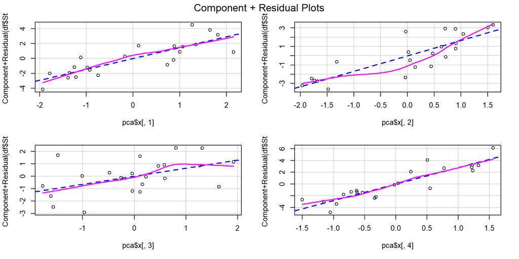

```r
crPlots(lm_reduced)
```

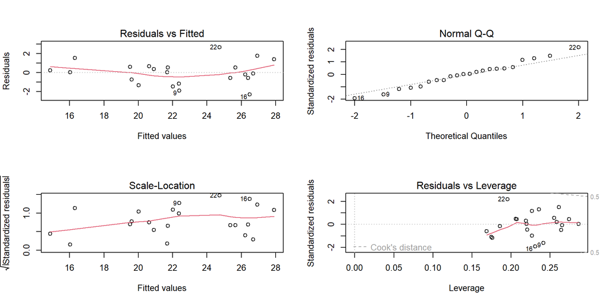

```r
par(mfrow=c(2,2))
plot(lm_reduced)
```

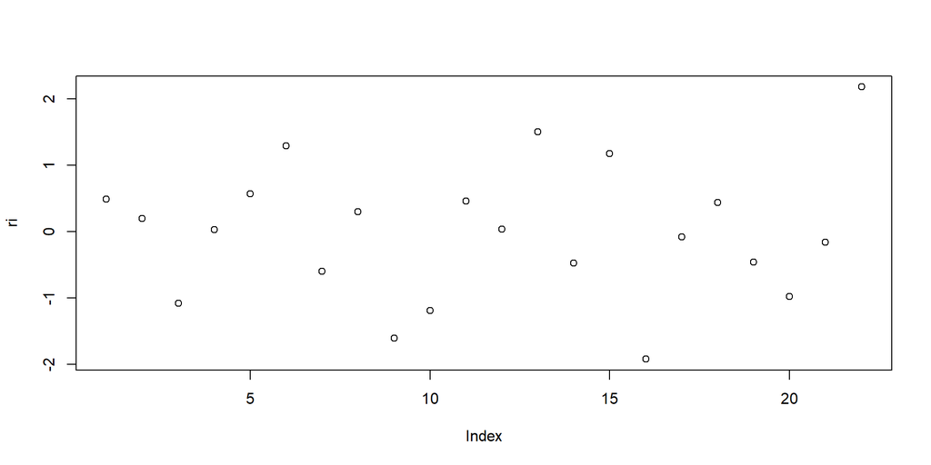

```r
ri <- rstandard(lm_reduced)
plot(ri)
```

```r
acf(lm_reduced$residuals, plot=FALSE)[1]
```

```
##
## Autocorrelations of series 'lm_reduced$residuals', by lag
##
##      1
## -0.125
```

```r
library(lmtest)
dwtest(lm_reduced, alternative='less')
```

```
##
##  Durbin-Watson test
##
## data:  lm_reduced
## DW = 2.0134, p-value = 0.5176
## alternative hypothesis: true autocorrelation is less than 0
```

After checking assumptions, the model seems fine.

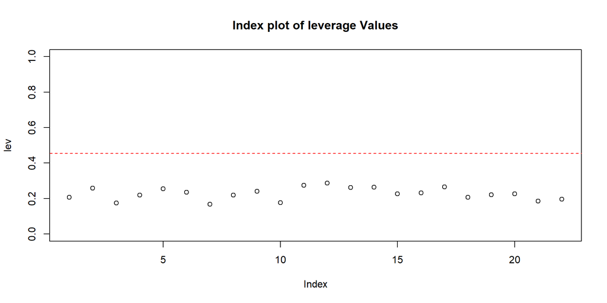

```r
p <- length(lm_reduced$coefficients)-1 ; n <- dim(df)[1]
lev <- influence(lm_reduced)$hat
reference_value <- 2*(p+1)/n
plot(lev, main='Index plot of leverage Values', ylim= c(0, 1)) # Calculate high leverage and plot lines.
abline(h = reference_value, lty=2, col = 'red') # identify(lev) no high leverage so I hide the code
```

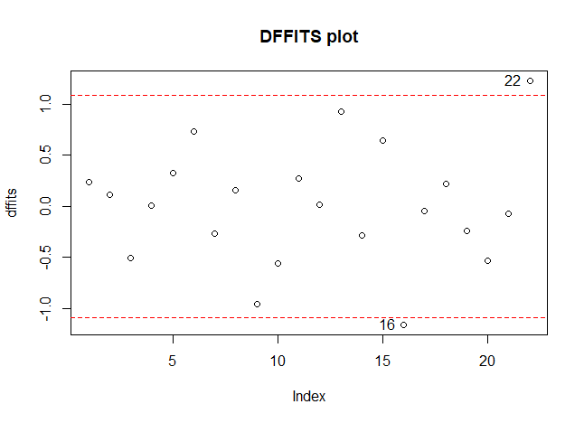

```r
dffits <- dffits(lm_reduced) # Using DFFITS to find influential points.
ref <- 2*sqrt((p+1)/(n-p-1))
plot(dffits, main='DFFITS plot')
abline(h= c(-ref,ref), col='red', lty=2)
identify(dffits)
```

Influential $(16, 22)^{th}$ points.

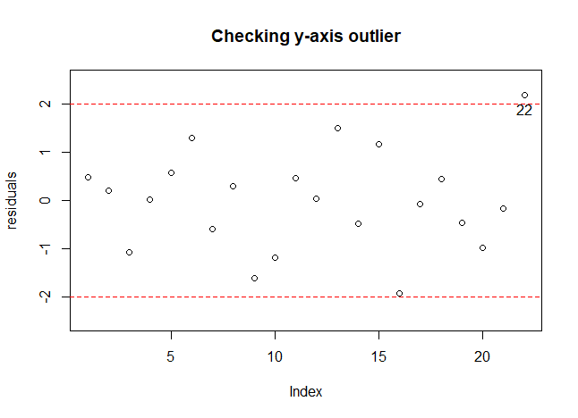

```r
residuals <- rstandard(lm_reduced) # Checking y-axis outliers w/ residual plot
plot(residuals, main='Checking y-axis outlier', ylim=c(-2.5, 2.5))
abline(h=c(-2,2), col='red', lty=2)
identify(residuals)
```

y-axis outlier = $22^{th}$ point.

### 3. Joint hypothesis test

$H_0 : \alpha_4= \alpha_5=0$  
$H_1 :$ not $H_0$, $\alpha=0.05$.

```r
lm_2_rdcd <- lm(df$St ~ pca$x[,1:3])
anova(lm_2_rdcd, lm_pca_full)
```

```
## Analysis of Variance Table
##
## Model 1: df$St ~ pca$x[, 1:3]
## Model 2: df$St ~ pca$x
##   Res.Df     RSS Df Sum of Sq      F    Pr(>F)
## 1     18 174.129
## 2     16  27.879  2    146.25 41.968 4.317e-07 ***
## ---
## Signif. codes:  0 '***' 0.001 '**' 0.01 '*' 0.05 '.' 0.1 ' ' 1
```

P-value = 4.317e-07 < 0.05($\alpha$). *Reject* $H_0 : \alpha_4= \alpha_5=0$.

### 4. Reduced model’s regression line

```r
eigen_matrix <- pca$rotation
eigen_matrix[, 2:4] <- -eigen_matrix[, 2:4]
eigen_matrix
```

```
##             PC1         PC2         PC3         PC4          PC5
## At   -0.5324451 -0.02378983  0.66774028  0.07441699  0.514316280
## Pt    0.2324522  0.82494494 -0.15779276 -0.03710662  0.489036183
## Et    0.3890860 -0.02207954  0.21720985  0.89490232 -0.009709995
## At.1 -0.3952282 -0.25963783 -0.69191108  0.33801805  0.428235605
## Pt.1  0.5957138 -0.50099959  0.05747436 -0.27924692  0.559323125
```

```r
co_1 <- c(); co_2 <- c(); co_3 <- c(); co_4 <- c()
for (i in 1:5){
  co_1 <- c(co_1, eigen_matrix[i,1])
  co_2 <- c(co_2, eigen_matrix[i,2])
  co_3 <- c(co_3, eigen_matrix[i,3])
  co_4 <- c(co_4, eigen_matrix[i,4])
}
```

$S_t$ = $\gamma_0$ + $\alpha_1$(-0.5324451$A^S_t$ + 0.2324522$P^S_t$ + 0.389086$E^S_{t}$ -0.3952282$A^S_{t-1}$ +0.5957138$P^S_{t-1}$)  
$\qquad$ $\;$ $\,$ + $\alpha_2$(-0.0237898$A^S_t$ + 0.8249449$P^S_t$ -0.0220795$E^S_{t}$ -0.2596378$A^S_{t-1}$-0.5009996$P^S_{t-1}$ )  
$\qquad$ $\;$ $\,$ + $\alpha_3$(0.6677403$A^S_t$ -0.1577928$P^S_t$ + 0.2172098$E^S_{t}$ -0.6919111$A^S_{t-1}$+ 0.0574744$P^S_{t-1}$)  
$\qquad$ $\;$ $\,$ + $\alpha_4$(0.074417$A^S_t$ -0.0371066$P^S_t$ + 0.8949023$E^S_{t}$ + 0.3380181$A^S_{t-1}$-0.2792469$P^S_{t-1}$) + $\epsilon$

```r
calc_gamma <- function(k){sum <- 0
for (i in 1:4){
sum <- sum + (eigen_matrix[k,i]*summary(lm_reduced)$coefficient[i+1,1]
)}
return(sum)
}
coef_list <- c(calc_gamma(1), calc_gamma(2),calc_gamma(3), calc_gamma(4), calc_gamma(5))
x_mean <- apply(df[,-1], 2, mean)
x_std <- apply(df[,-1], 2, sd)
coef_list
```

```
## [1] -0.1758737  1.5075815  3.1882747 -0.5067823 -0.7130527
```

$S_t$ = 22.4757914 -0.1758737$A^S_t$ + 1.5075815$P^S_t$ + 3.1882747$E^S_{t}$ -0.5067823$A^S_{t-1}$ -0.7130527$P^S_{t-1}$ + $\epsilon$.

Transform standardized variables to Original variables. Using $\gamma_jX^S_{ij}$ = $\gamma_jX_{ij}\over s_j$-$\gamma_j\bar{X_{j}}\over s_j$, where $X^S_{ij}$ = $X_{ij}-\bar{X_{j}}\over s_j$.

```r
adj_coef <- c()
coef_slope <- c() # gamma divide by std of x_j
for(i in 1:5){
  coef_slope <- c(coef_slope, coef_list[i]/x_std[i])
  adj_coef <- c(adj_coef, -coef_slope[i]*x_mean[i])
}
coef_slope
```

```
##         At         Pt         Et       At.1       Pt.1
## -0.4046061  3.2443191 22.8602737 -1.2364592 -1.4615889
```

```r
adj_coef
```

```
##          At          Pt          Et        At.1        Pt.1
##   0.7092572  -2.4479863 -11.2742713   2.2208004   1.0363994
```

```r
intercept <- lm_reduced$coefficient[1] + sum(adj_coef)
intercept
```

```
## (Intercept)
##    12.71999
```

$S_t$ = 12.7199907 -0.4046061$A_t$ + 3.2443191$P_t$ + 22.8602737$E_{t}$ -1.2364592$A_{t-1}$ -1.4615889$P_{t-1}$ + $\epsilon$.

## 1 - (6)

### 1. Source of multicollinearity

In 1-(5), hypothesis test.  
$H_0 : \alpha_5 = 0$  
$H_1 : \alpha_5\neq 0$, $\alpha=0.05$.  
*We can’t reject* $H_0 : \alpha_5 = 0$*.*

$H_0 : \alpha_4= \alpha_5=0$  
$H_1 :$ not $H_0$, $\alpha=0.05$.  
*Reject* $H_0 : \alpha_4= \alpha_5=0$.  
And in 1-(2), we saw relationship between (At = Pt + At.1 + Pt.1) regression model.

*So we can claim 1 PC(=PC5) is the source of multicollinearity.*

### 2. Standardized variables

```r
eigen_matrix
```

```
##             PC1         PC2         PC3         PC4          PC5
## At   -0.5324451 -0.02378983  0.66774028  0.07441699  0.514316280
## Pt    0.2324522  0.82494494 -0.15779276 -0.03710662  0.489036183
## Et    0.3890860 -0.02207954  0.21720985  0.89490232 -0.009709995
## At.1 -0.3952282 -0.25963783 -0.69191108  0.33801805  0.428235605
## Pt.1  0.5957138 -0.50099959  0.05747436 -0.27924692  0.559323125
```

```r
coef_5 <- c()
for (i in 1:5){
coef_5 <- c(coef_5, eigen_matrix[i,5])
}
coef_5
```

```
## [1]  0.514316280  0.489036183 -0.009709995  0.428235605  0.559323125
```

$\alpha_5$ = 0.5143163$A^S_t$ +0.4890362$P^S_t$ -0.00971$E^S_t$ + 0.4282356$A^S_{t-1}$ + 0.5593231$P^S_{t-1}$ = 0

### 3. Original variables

$\mathcal{V}_{ij}X^S_{ij}$ = $\mathcal{V}_{ij}X_{ij}\over s_j$-$\mathcal{V}_{ij}\bar{X_{j}}\over s_j$, where $X^S_{ij}$ = $X_{ij}-\bar{X_{j}}\over s_j$.

```r
const_5 <- c()
coef_org <- c()
for(i in 1:5){
  coef_org <- c(coef_org, coef_5[i]/x_std[i])
  const_5 <- c(const_5, coef_org[i]*x_mean[i]) # remove - sign since it will go to rhs
}
coef_org
```

```
##          At          Pt          Et        At.1        Pt.1
##  1.18321004  1.05240708 -0.06962172  1.04481906  1.14647977
```

```r
const_5
```

```
##          At          Pt          Et        At.1        Pt.1
##  2.07411665  0.79408898 -0.03433616  1.87659619  0.81295839
```

```r
rhs <- sum(const_5); rhs
```

```
## [1] 5.523424
```

$\alpha_5$ = 1.18321$A_t$ +1.0524071$P_t$ -0.0696217$E_t$ + 1.0448191$A_{t-1}$ + 1.1464798$P_{t-1}$ = 5.523424

### 4. Beta notation

$\alpha_5$ = 0.5143163$\gamma_1$ + 0.4890362$\gamma_2$ -0.00971$\gamma_3$ + 0.4282356$\gamma_4$ + 0.5593231$\gamma_5$ = 0, where $\gamma_j$ = $s_j\beta_j$.

```r
x_std
```

```
##        At        Pt        Et      At.1      Pt.1
## 0.4346788 0.4646835 0.1394679 0.4098658 0.4878613
```

```r
for(i in 1:5){assign(paste0('g',1:5)[i], eigen_matrix[i,5]*x_std[i])
}
```

We can use approximation, but I’ve just calculated exact values.

$\alpha_5$ = 0.2235624$\beta_1$ + 0.227247$\beta_2$ -0.0013542$\beta_3$ + 0.1755191$\beta_4$ + 0.2728721$\beta_5$ = 0.